# School Shootings Happen More and More Despite Changing Policies and Party

Mai Kubin

2026-04-11

[interactive chart not shown]

School shootings have significantly increased over time, from under 10 to above 350 shootings per year at its peak. As of April 13th, 2026, there have been 57 school shootings. Despite policy changes year after year, these numbers have skyrocketed, particularly post-COVID.

Most states have experienced vast increases in the number of school shootings they’ve seen, with California and Ohio reaching record high numbers in 2023.

[interactive chart not shown]

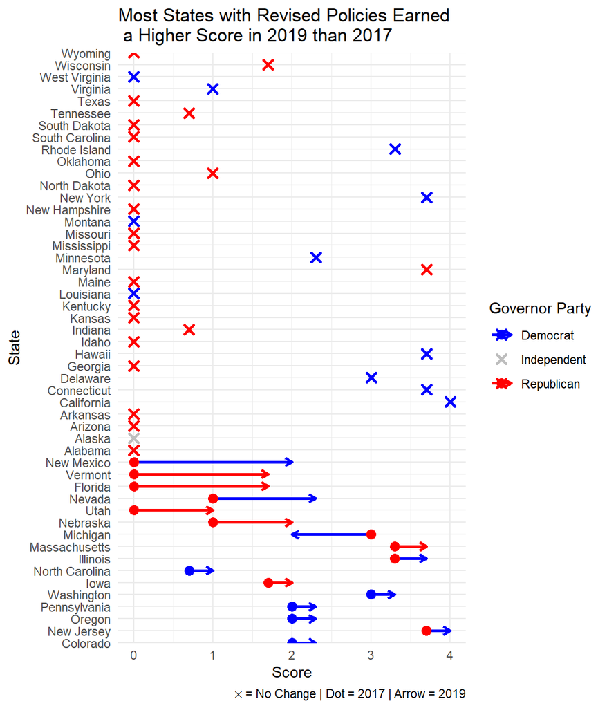

Focusing on policy changes before and after the shooting in Parkland, Florida, shows that states improved their policies*, regardless of the governor’s party, with the exception of Michigan. These changes could be attributed to the nationwide March for Our Lives movement, which was sparked by the Parkland shooting.

*Scoring based on the Gifford Law Center’s grading scale

However, this graph shows that, despite some positive policy changes, the number of school shootings still increased in 2019, and in the post-COVID era. The most pressing question is why the rate of occurrences is still increasing in spite of efforts to prevent school shootings?

[interactive chart not shown]

Bibliography:

“Former Governors.” n.d. National Governors Association. https://www.nga.org/former-governors/.

“Giffords Law Center’s Annual Gun Law Scorecard.” 2017. Giffords Law Center. 2017. https://giffords.org/lawcenter/resources/scorecard2017/.

“Giffords Law Center’s Annual Gun Law Scorecard.” 2019. Giffords Law Center. 2019. https://giffords.org/lawcenter/resources/scorecard2019/.

Riedman, David (2025). K-12 School Shooting Database

Social Explorer; U.S. Census Bureau. Total Population, 2019. Prepared by Social Explorer. https://www.socialexplorer.com/data/ACS2019_5yr/metadata?ds=SE&table=A00001 (accessed 27 April 2026 at 01:16:54 GMT-4).